# Actividad 1.3

2026-07

# Obtención y limpieza de datos

## Paso 1. Obtención de los conjuntos de datos

```r
library(readr)
registros<-read_csv("registries.csv")
head(registros)
```

```
## # A tibble: 6 × 6
##      ID date       entry_time       exit_time        n_views n_buy
##   <dbl> <chr>      <chr>            <chr>              <dbl> <dbl>
## 1  1254 01/07/2025 01/07/2025 16:46 01/07/2025 18:46       4     1
## 2  1433 01/07/2025 01/07/2025 13:12 01/07/2025 13:50       1     0
## 3  1433 01/07/2025 01/07/2025 16:46 01/07/2025 18:46      32     2
## 4  1510 04/07/2025 04/07/2025 17:41 04/07/2025 18:04      31     1
## 5  2262 04/07/2025 04/07/2025 18:17 04/07/2025 18:27      12     0
## 6  2567 30/06/2025 30/06/2025 15:47 30/06/2025 18:42      21     1
```

```r
clientes<-read_csv("clients.csv")
head(clientes)
```

```
## # A tibble: 6 × 3
##      ID category city_country
##   <dbl> <chr>    <chr>
## 1  1254 Silver   Quito-Ecuador
## 2  1433 Silver   Guayaquil-Ecuador
## 3  1510 Silver   Cuenca-Ecuador
## 4  2262 Silver   Loja-Ecuador
## 5  2567 Silver   Manta-Ecuador
## 6  2682 Silver   Ambato-Ecuador
```

## Paso 2. Exploración

```r
#para entender la estructura del conjunto y las clases de las variables
str(registros)
```

```
## spc_tbl_ [10,828 × 6] (S3: spec_tbl_df/tbl_df/tbl/data.frame)
##  $ ID        : num [1:10828] 1254 1433 1433 1510 2262 ...
##  $ date      : chr [1:10828] "01/07/2025" "01/07/2025" "01/07/2025" "04/07/2025" ...
##  $ entry_time: chr [1:10828] "01/07/2025 16:46" "01/07/2025 13:12" "01/07/2025 16:46" "04/07/2025 17:41" ...
##  $ exit_time : chr [1:10828] "01/07/2025 18:46" "01/07/2025 13:50" "01/07/2025 18:46" "04/07/2025 18:04" ...
##  $ n_views   : num [1:10828] 4 1 32 31 12 21 33 13 22 33 ...
##  $ n_buy     : num [1:10828] 1 0 2 1 0 1 2 0 1 2 ...
##  - attr(*, "spec")=
##   .. cols(
##   ..   ID = col_double(),
##   ..   date = col_character(),
##   ..   entry_time = col_character(),
##   ..   exit_time = col_character(),
##   ..   n_views = col_double(),
##   ..   n_buy = col_double()
##   .. )
##  - attr(*, "problems")=<externalptr>
```

```r
str(clientes)
```

```
## spc_tbl_ [3,902 × 3] (S3: spec_tbl_df/tbl_df/tbl/data.frame)
##  $ ID          : num [1:3902] 1254 1433 1510 2262 2567 ...
##  $ category    : chr [1:3902] "Silver" "Silver" "Silver" "Silver" ...
##  $ city_country: chr [1:3902] "Quito-Ecuador" "Guayaquil-Ecuador" "Cuenca-Ecuador" "Loja-Ecuador" ...
##  - attr(*, "spec")=
##   .. cols(
##   ..   ID = col_double(),
##   ..   category = col_character(),
##   ..   city_country = col_character()
##   .. )
##  - attr(*, "problems")=<externalptr>
```

```r
#estadística descriptiva base por columna para identificar posibles problemas
summary(registros)
```

```
##        ID            date            entry_time         exit_time
##  Min.   : 1254   Length:10828       Length:10828       Length:10828
##  1st Qu.:33291   Class :character   Class :character   Class :character
##  Median :37642   Mode  :character   Mode  :character   Mode  :character
##  Mean   :36420
##  3rd Qu.:40331
##  Max.   :42285
##
##     n_views            n_buy
##  Min.   :   1.00   Min.   : 0.000
##  1st Qu.:  13.00   1st Qu.: 1.000
##  Median :  20.00   Median : 2.000
##  Mean   :  20.29   Mean   : 2.633
##  3rd Qu.:  27.00   3rd Qu.: 4.000
##  Max.   :1000.00   Max.   :16.000
##  NA's   :5
```

```r
summary(clientes)
```

```
##        ID          category         city_country
##  Min.   : 1254   Length:3902        Length:3902
##  1st Qu.:32362   Class :character   Class :character
##  Median :36413   Mode  :character   Mode  :character
##  Mean   :35619
##  3rd Qu.:39701
##  Max.   :42285
```

```r
# para identificar categorías inconstistentes
table(clientes$category)
```

```
##
##      Gold Platinium    Silver     Silvr
##       954       438      2503         4
```

```r
# para identificar columnas con valores faltantes
colSums(is.na(registros))
```

```
##         ID       date entry_time  exit_time    n_views      n_buy
##          0          0          0          0          5          0
```

```r
colSums(is.na(clientes))
```

```
##           ID     category city_country
##            0            3            0
```

## Paso 3. Limpieza

```r
library(dplyr)
library(tidyr)

#### Corregir inconsistencias en variables categóricas ----

# Reemplazar el texto mal escrito "Silvr" por "Silver"
clientes <- clientes %>%
  mutate(category = ifelse(category == "Silvr", "Silver", category))


#### Imputar valores faltantes ----

# Obtener la categoría más frecuente (moda)
moda_category <- names(which.max(table(clientes$category)))

# Reemplazar las categorías faltantes por la moda
clientes <- clientes %>%
  replace_na(list(category = moda_category))


# Calcular la media del número de vistas
media_views <- mean(registros$n_views, na.rm = TRUE)

# Reemplazar los valores faltantes por la media
registros <- registros %>%
  replace_na(list(n_views = media_views))

# Alternativa: eliminar los registros que tengan valores faltantes
# En este caso se crea un nuevo conjunto de datos, conservando el original.
registros_sin_na <- registros %>%
  drop_na()

# También es posible eliminar filas con NA únicamente en una variable específica:
# registros_sin_na <- registros %>%
#   drop_na(n_views)

#### Transformar variables ----

# Convertir las fechas y horas al formato fecha-hora
registros <- registros %>%
  mutate(
    entry_time = as.POSIXct(entry_time, format= "%d/%m/%Y %H:%M"),
    exit_time  = as.POSIXct(exit_time, format= "%d/%m/%Y %H:%M")
  )

# Calcular el tiempo de conexión
registros <- registros %>%
  mutate(time = exit_time - entry_time)


#### Detectar inconsistencias ----

# Identificar registros cuyo tiempo de conexión es negativo
registros %>%
  filter(time < 0)
```

```
## # A tibble: 1 × 7
##      ID date       entry_time          exit_time           n_views n_buy time
##   <dbl> <chr>      <dttm>              <dttm>                <dbl> <dbl> <drtn>
## 1 27747 03/07/2025 2025-07-03 13:09:00 2025-07-03 13:01:00      11     2 -480 s…
```

```r
#registrar inconsitencia para revisión posterior revisión con sistemas
registros <- registros %>%
  mutate(
    inconsistente = ifelse(time < 0, "Si", "No")
  )

#### Detectar y corregir valores extremos ----

# Calcular el límite superior utilizando el criterio del IQR
Q1 <- quantile(registros$n_views, 0.25)
Q3 <- quantile(registros$n_views, 0.75)
IQRv <- IQR(registros$n_views)

limSup <- Q3 + 1.5 * IQRv

registros %>%
  filter(n_views > limSup)
```

```
## # A tibble: 30 × 8
##       ID date       entry_time          exit_time           n_views n_buy time
##    <dbl> <chr>      <dttm>              <dttm>                <dbl> <dbl> <drtn>
##  1 24791 02/07/2025 2025-07-02 15:03:00 2025-07-02 16:02:00      54     2 3540 …
##  2 27198 04/07/2025 2025-07-04 14:54:00 2025-07-04 14:55:00      49     1   60 …
##  3 27230 03/07/2025 2025-07-03 17:56:00 2025-07-03 20:00:00    1000     3 7440 …
##  4 29518 01/07/2025 2025-07-01 18:10:00 2025-07-01 19:53:00      49     2 6180 …
##  5 31741 30/06/2025 2025-06-30 17:16:00 2025-06-30 18:32:00      50     3 4560 …
##  6 32246 03/07/2025 2025-07-03 16:08:00 2025-07-03 16:17:00      50     2  540 …
##  7 32281 30/06/2025 2025-06-30 13:06:00 2025-06-30 15:37:00      57     1 9060 …
##  8 32391 04/07/2025 2025-07-04 15:11:00 2025-07-04 17:49:00      51     1 9480 …
##  9 32469 30/06/2025 2025-06-30 17:52:00 2025-06-30 18:47:00      49     3 3300 …
## 10 35247 07/07/2025 2025-07-07 19:02:00 2025-07-07 19:56:00      50     3 3240 …
## # ℹ 20 more rows
## # ℹ 1 more variable: inconsistente <chr>
```

```r
#Solo reemplazar los valores muy extremos por la media

registros %>%
  filter(n_views > limSup) %>% select(n_views) %>% summary()
```

```
##     n_views
##  Min.   :  49.00
##  1st Qu.:  49.00
##  Median :  50.00
##  Mean   :  82.27
##  3rd Qu.:  51.00
##  Max.   :1000.00
```

```r
registros <- registros %>%
  mutate(
    n_views = ifelse(n_views > 52,
                     media_views,
                     n_views)
)

registros %>% select(n_views) %>% summary()
```

```
##     n_views
##  Min.   : 1.00
##  1st Qu.:13.00
##  Median :20.00
##  Mean   :20.19
##  3rd Qu.:27.00
##  Max.   :52.00
```

# Procesamiento y análisis descriptivo de datos

## Paso 4. Procesamiento de datos

En esta sección se presentan algunas de las funciones más utilizadas de los paquetes *dplyr* y *tdyr* para manipular conjuntos de datos. El objetivo es construir un conjunto de datos listo para el análisis, a partir de los archivos de registros de navegación y de información de clientes.

En particular, se aprenderá a:

- Unir dos conjuntos de datos mediante una variable común.
- Filtrar observaciones que cumplen una determinada condición.
- Seleccionar únicamente las variables de interés para el análisis.

Cada una de estas operaciones genera un nuevo conjunto de datos o una nueva vista de la información, sin modificar necesariamente los datos originales.

```r
#library(dplyr)
#library(tidyr)

# Separar una variable en dos columnas utilizando el guion como separador
clientes <- clientes %>%
  separate(
    city_country,
    into = c("city", "country"),
    sep = "-"
  )

head(clientes)
```

```
## # A tibble: 6 × 4
##      ID category city      country
##   <dbl> <chr>    <chr>     <chr>
## 1  1254 Silver   Quito     Ecuador
## 2  1433 Silver   Guayaquil Ecuador
## 3  1510 Silver   Cuenca    Ecuador
## 4  2262 Silver   Loja      Ecuador
## 5  2567 Silver   Manta     Ecuador
## 6  2682 Silver   Ambato    Ecuador
```

```r
# Volver a unir las columnas en una sola variable manteniendo también
#las variables separadas
clientes <- clientes %>%
  unite(
    city_country,
    city,
    country,
    sep = "-", remove = F
  )

head(clientes)
```

```
## # A tibble: 6 × 5
##      ID category city_country      city      country
##   <dbl> <chr>    <chr>             <chr>     <chr>
## 1  1254 Silver   Quito-Ecuador     Quito     Ecuador
## 2  1433 Silver   Guayaquil-Ecuador Guayaquil Ecuador
## 3  1510 Silver   Cuenca-Ecuador    Cuenca    Ecuador
## 4  2262 Silver   Loja-Ecuador      Loja      Ecuador
## 5  2567 Silver   Manta-Ecuador     Manta     Ecuador
## 6  2682 Silver   Ambato-Ecuador    Ambato    Ecuador
```

```r
# Unir la información de registros y clientes utilizando la variable ID.
# El resultado solo incluye los clientes que aparecen en ambos conjuntos de datos.
registros2 <- inner_join(registros, clientes, by = "ID")


# Crear un nuevo conjunto de datos que contenga únicamente
# los clientes cuya categoría es "Silver".
registros2_silver <- registros2 %>%
  filter(category == "Silver")


# Mostrar únicamente las variables ID, número de visitas y número de compras.
# select() no modifica el conjunto de datos; simplemente presenta
# las columnas indicadas.
registros2 %>%
  select(ID, n_views, n_buy)
```

```
## # A tibble: 10,828 × 3
##       ID n_views n_buy
##    <dbl>   <dbl> <dbl>
##  1  1254       4     1
##  2  1433       1     0
##  3  1433      32     2
##  4  1510      31     1
##  5  2262      12     0
##  6  2567      21     1
##  7  2567      33     2
##  8  2682      13     0
##  9  2701      22     1
## 10  2701      33     2
## # ℹ 10,818 more rows
```

Para fortalecer tu aprendizaje, aquí sería bueno que te preguntes:

- ¿Qué información se obtuvo al unir registros y clientes?
- ¿Qué diferencia hay entre registros2 y registros2_silver?
- ¿La función select() elimina columnas del conjunto de datos o solo las muestra?
- ¿Qué análisis podría hacer a partir de registros2?

## Paso 5. Análisis descriptivo de datos

```r
registros2 %>% summary
```

```
##        ID            date             entry_time
##  Min.   : 1254   Length:10828       Min.   :2025-06-27 13:00:00
##  1st Qu.:33291   Class :character   1st Qu.:2025-06-30 18:00:00
##  Median :37642   Mode  :character   Median :2025-07-02 17:21:00
##  Mean   :36420                      Mean   :2025-07-02 19:26:23
##  3rd Qu.:40331                      3rd Qu.:2025-07-04 14:42:00
##  Max.   :42285                      Max.   :2025-07-07 22:26:00
##    exit_time                      n_views          n_buy
##  Min.   :2025-06-27 13:19:00   Min.   : 1.00   Min.   : 0.000
##  1st Qu.:2025-06-30 19:02:00   1st Qu.:13.00   1st Qu.: 1.000
##  Median :2025-07-02 18:34:00   Median :20.00   Median : 2.000
##  Mean   :2025-07-02 20:47:19   Mean   :20.19   Mean   : 2.633
##  3rd Qu.:2025-07-04 16:12:00   3rd Qu.:27.00   3rd Qu.: 4.000
##  Max.   :2025-07-07 22:55:00   Max.   :52.00   Max.   :16.000
##       time            inconsistente        category         city_country
##  Min.   : -480 secs   Length:10828       Length:10828       Length:10828
##  1st Qu.: 1800 secs   Class :character   Class :character   Class :character
##  Median : 4020 secs   Mode  :character   Mode  :character   Mode  :character
##  Mean   : 4855 secs
##  3rd Qu.: 7020 secs
##  Max.   :32100 secs
##      city             country
##  Length:10828       Length:10828
##  Class :character   Class :character
##  Mode  :character   Mode  :character
##
##
##
```

Podemos resumir la información por categoría de cliente. La función group_by() agrupa las observaciones y summarise() calcula estadísticas descriptivas para cada grupo.

```r
registros2 %>% group_by(category) %>% summarise(total_login=n(), total_compras=sum(n_buy), tiempo_promedio=mean(time))
```

```
## # A tibble: 3 × 4
##   category  total_login total_compras tiempo_promedio
##   <chr>           <int>         <dbl> <drtn>
## 1 Gold             3101          9436 4601.580 secs
## 2 Platinium        1540         12324 4161.039 secs
## 3 Silver           6187          6752 5154.947 secs
```

Podemos visualizar las relaciones entre las variables mediante un gráfico de pares. La función ggpairs() permite explorar de forma simultánea la distribución de cada variable y su relación con las demás.

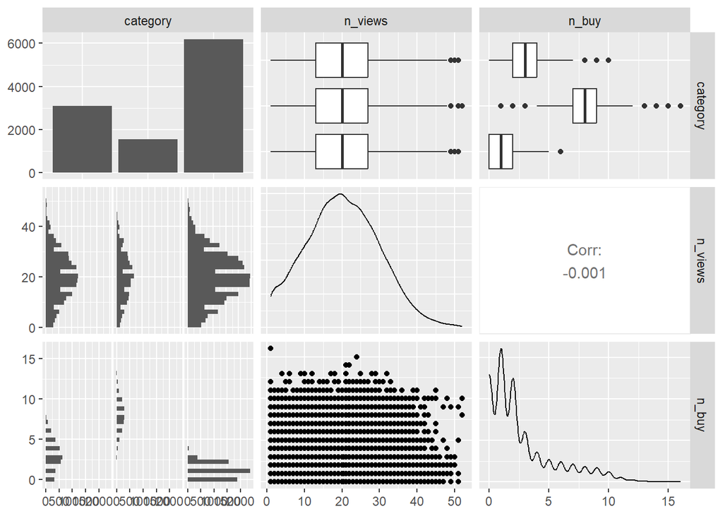

```r
library(GGally)
registros2 %>% select(category, n_views, n_buy) %>% ggpairs()
```

#Actividad para seguir practicando

1. Crea una tabla donde se muestre el número de logins realizados por cada cliente y el tiempo promedio de conexión.
2. Crea una variable denominada purchase que tome el valor “Sí” cuando n_buy > 0 y “No” en caso contrario. Incorpórela al gráfico de pares.
3. Redacte un resumen ejecutivo con los principales hallazgos obtenidos después del análisis.